# A5_report

Brian Amaro & Vivek Vajipey

3/15/2022

The topic of air quality has been increasingly concerning recently, especially in the Bay Area. The private company PurpleAir has developed widely applicable air quality sensors that can measure the levels of PM2.5 both indoors and outdoors. PM2.5, or any airborne particulate matter that is less than 2.5 micrometers wide, includes dust, dirt, soot, and wildfire smoke. According to NOAA, PM2.5 is particularly concerning due to its connection to various health concerns, such as “lung irritation and inflammation, asthma attacks, wheezing, coughing, and increased susceptibility to respiratory illnesses.” Considering the importance of PM2.5 exposure to public health, it is important to research its distribution in the Bay Area. This report and the associated dashboard use PurpleAir sensor data in San Mateo County to assess the equity implications of air quality. In order to familiarize oneself with the location, a map of the sensors can be seen below.

[interactive chart not shown]

Our methodology for collecting data for the geographic equity is using the Thingspeak API that PurpleAir uses to store historical data. For all the outdoor sensors in the cities of interest, we saved the entirety of February’s data and calculated a daily average for our time series analysis.

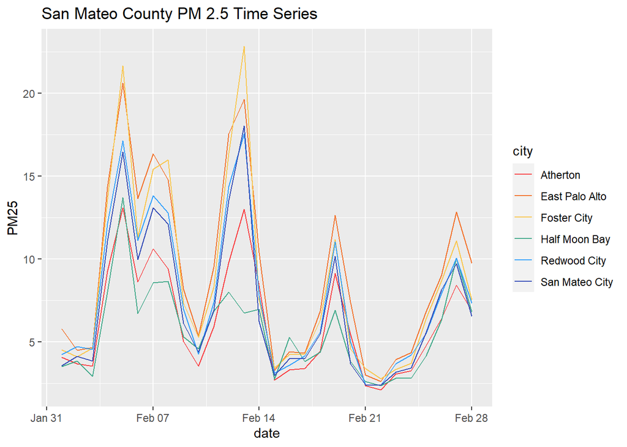

The comparison of the selected cities in San Mateo County reveals that many of the cities have very similar trends in PM2.5 variations. Since many air quality influencing factors, such as wildfires, have regional-scale impacts, the similarity in trends makes sense. Unlike the other cities, PM2.5 levels at Half Moon Bay do not drastically increase near February 12, which is expected due to it being far less urbanized.

For the map analysis, we calculated a monthly average for each sensor. We then used the Voronoi technique to extrapolate sensor data to their surroundings so that we can map out the sparse sensor data to the entirety of the Census block groups of each city of interest..

The result of this analysis for one location can be seen in the map below of Atherton along with the outdoor sensors.

[interactive chart not shown]

After doing this analysis for Atherton, we extended the same sort of analysis for East Palo Alto, Foster City, Half Moon Bay, Millbrae, Portola Valley, Redwood City, San Mateo, and South San Francisco. The result of this analysis can be seen in the map below.

[interactive chart not shown]

The map has several key takeaways of air pollution’s geographic impact. The most notable is that the area closer to the actual bay has higher levels of PM2.5. This makes sense as those areas are more densely populated. Additionally, East Palo Alto appears to have some of the highest measures of PM2.5 as well as being one of the poorer communities around it, helping provide evidence that poorer communities face higher levels of air pollution.

We additionally performed a population-based equity analysis of San Mateo County’s exposure to PM2.5. This was done by getting census demographic data for the county and combining it with the PM2.5 sensor data, assuming that the household’s sensor is representative of the entire census geography. Our first analysis investigated the trends in PM2.5 levels to the race of the householder using race data at the census block level.

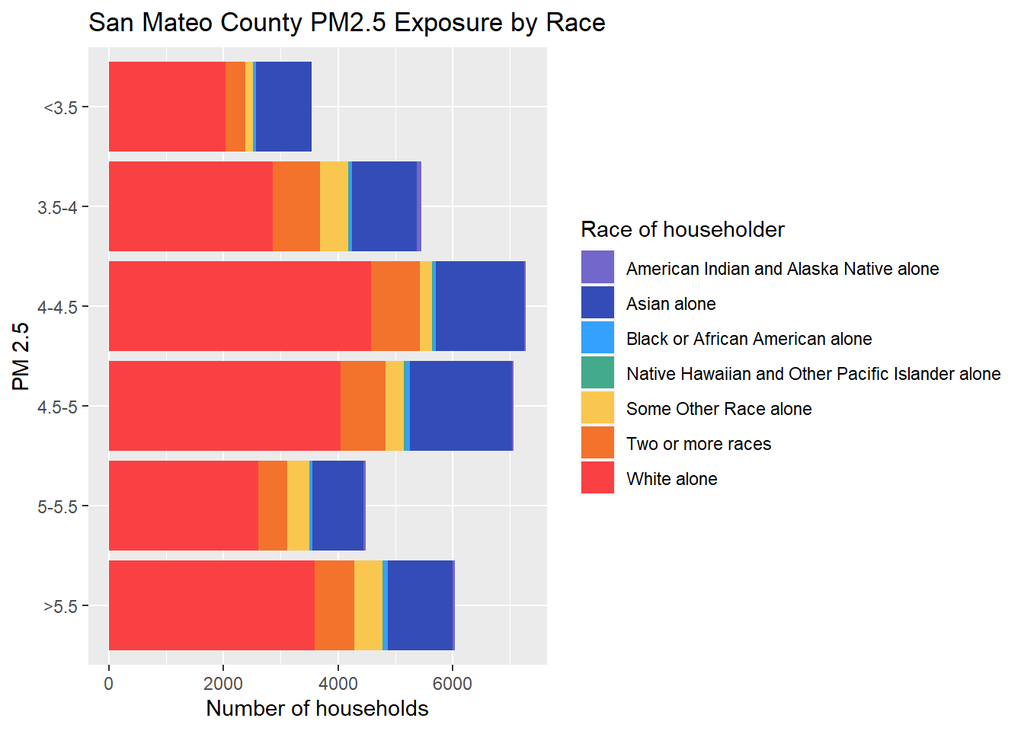

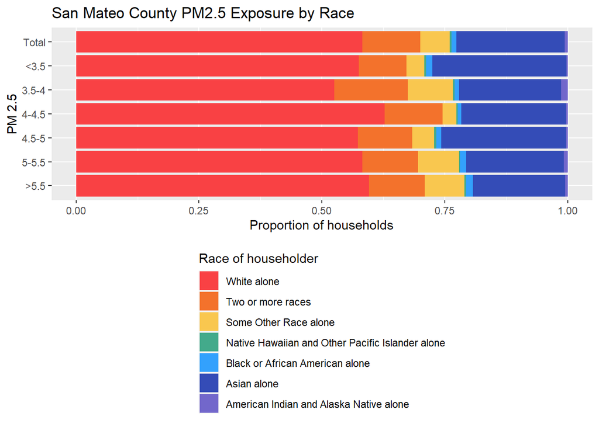

We also performed an equity analysis based on household income using ACS data at the census block group level.

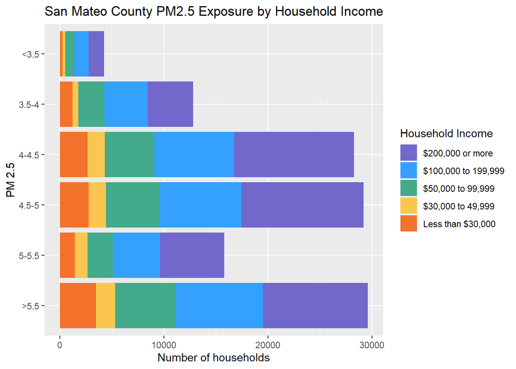

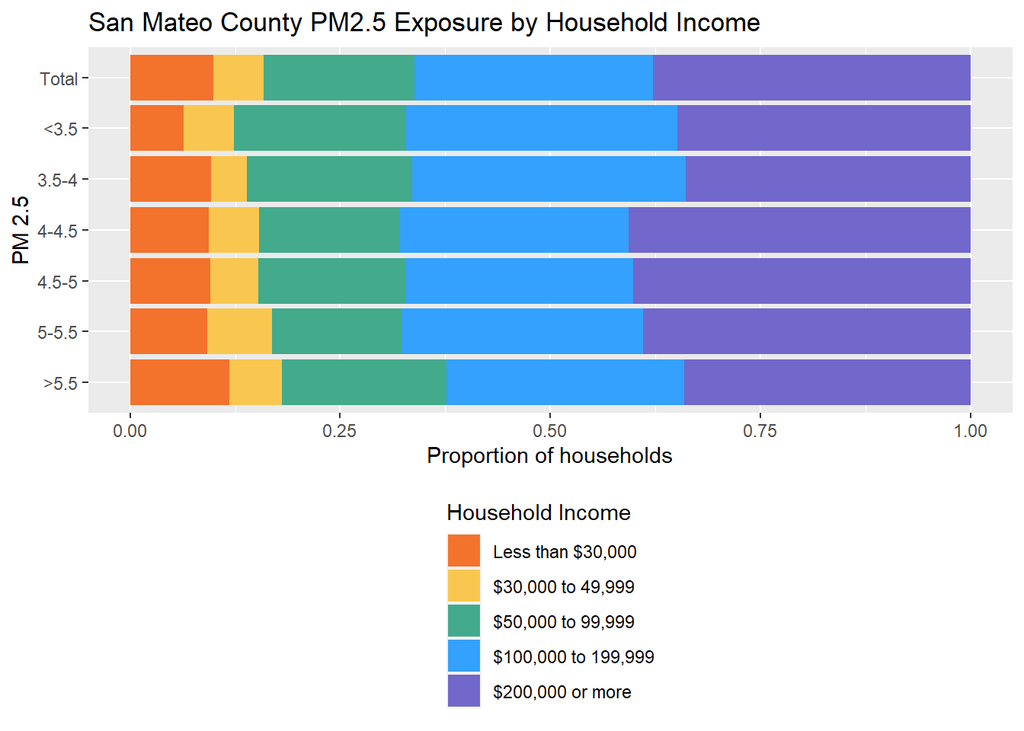

Note that we divided our income brackets to roughly match the income group breakdown by George Washington research professor Stephen Rose which can be found here https://money.usnews.com/money/personal-finance/family-finance/articles/where-do-i-fall-in-the-american-economic-class-system. Essentially our categories are meant to represent poor, lower-middle class, middle class, upper-middle class, and rich. One should note that Rose’s breakdown was created in mind for the national household income distribution and thus does not account for the high cost of living in San Mateo County. Thus we have refrained from labeling our brackets with the specific classes from Rose’s breakdown to avoid misrepresentation.

One key takeaway from these results is that the lowest income bracket has fewer households with low PM2.5 exposure while a greater number of low income households have higher PM2.5 exposure. This implies that lower income households are more likely to have worse air quality. Additionally, the highest income is also less likely to have high PM2.5 exposure, further showing air quality inequity based on income differences.

Our results are a good preliminary analysis but suggest that further investigation should be done to assess the equity implications of air quality.